# ADAC Testnoten

2024-03-19

## Ausgangslage

- Vollerhebung der in Deutschland zugelassenen und vom ADAC getesteten Automodelle
- Quelle: Webscraping der ADAC-Testseiten
- Datensatz mit 3800 Modelle (Zeilen) und 364 Fahrzeugeigenschaften (Spalten)
- Ziel: Datensatz bereinigen

## Motivation

- Validierung und Bereinigung des Datensatzes
- Darstellung von Verteilungen und Zusammenhänge interessanter Variablen über die Zeit
- Darstellung von Assoziationen zwischen Fahrzeugeigenschaften und der ADAC-Gesamtpunktzahl

## Validierung und Bereinigung

- Alle fehlenden Einträge zu NA ersetzt
- Leere Fahrzeugeigenschaften entfernt
- Doppelte Modelle entfernt
- 1056 Zeilen entfernt
- 75 Spalten entfernt

## Darstellung von Verteilungen und Zusammenhänge interessanter Variablen über die Zeit

- CO2-Ausstoß
- Motorarten
- Kosten
- Fahrzeuggröße
- Elektroautos

## CO2-Ausstoß

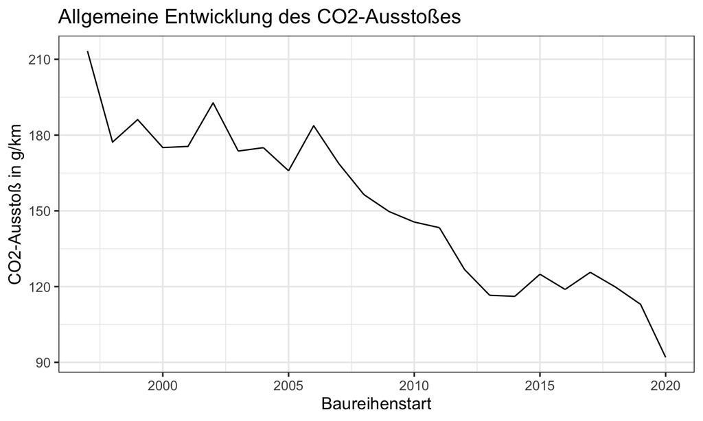

## CO2 Effizienzklasse

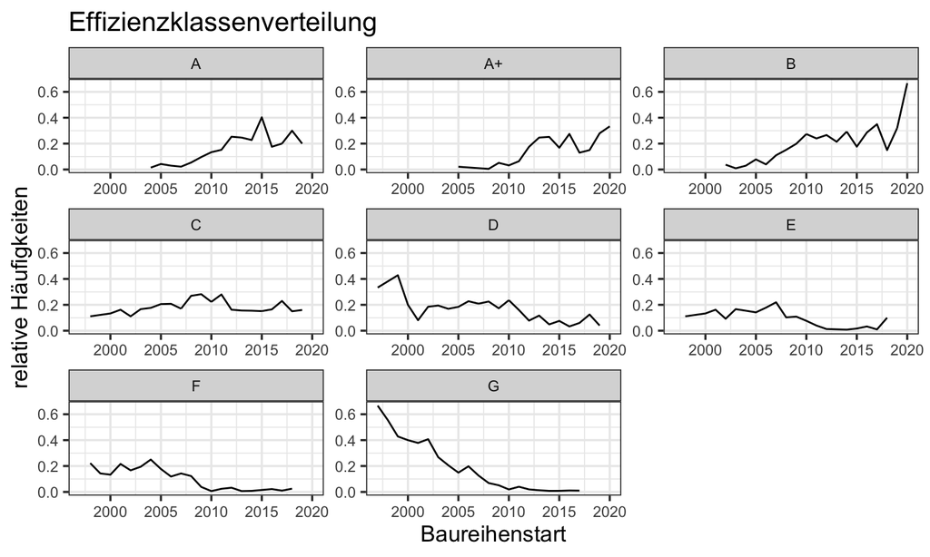

## CO2-Ausstoß Fahrzeugklasse und PS

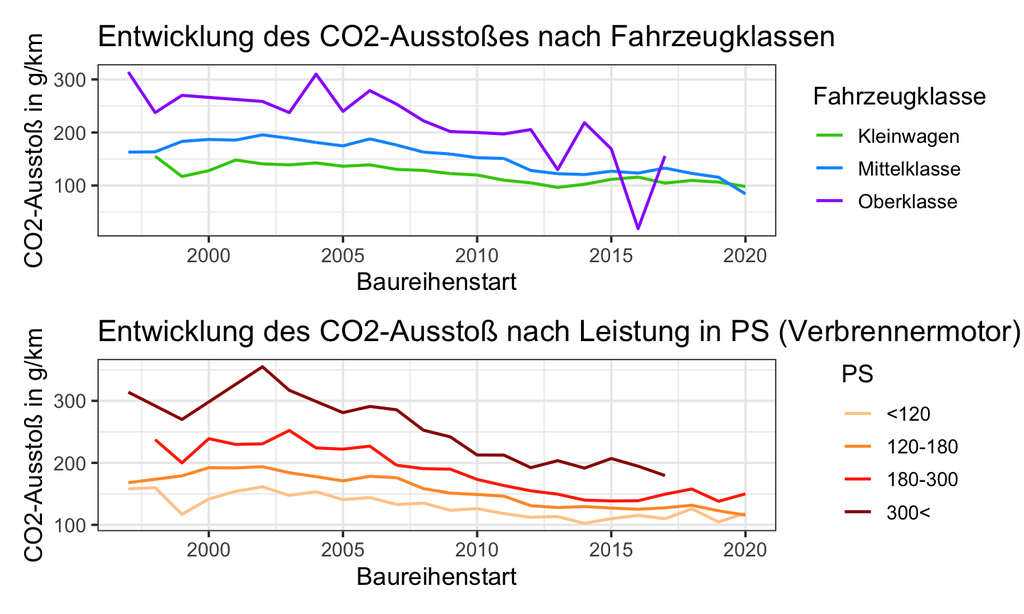

## Verhältnis zwischen ADAC-Ecotest und Herstellerangabe

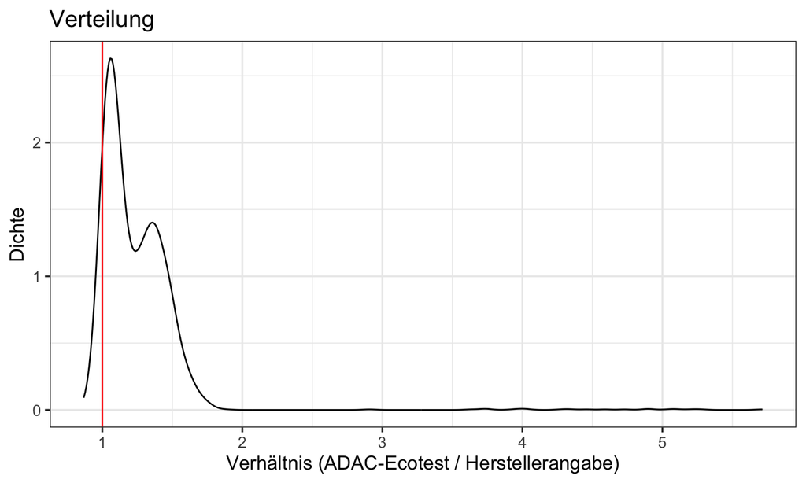

## Vergleich zwischen ADAC-Ecotest und Herstellerangabe

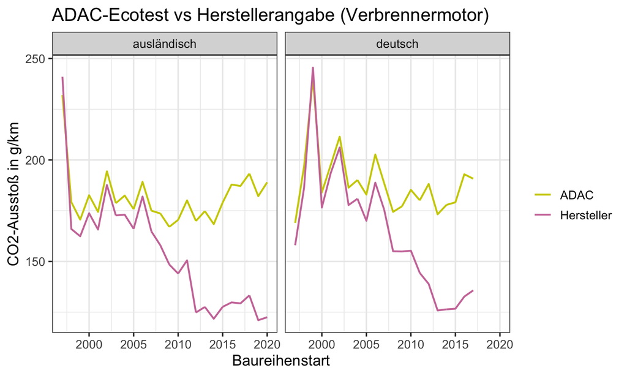

## Motorarten

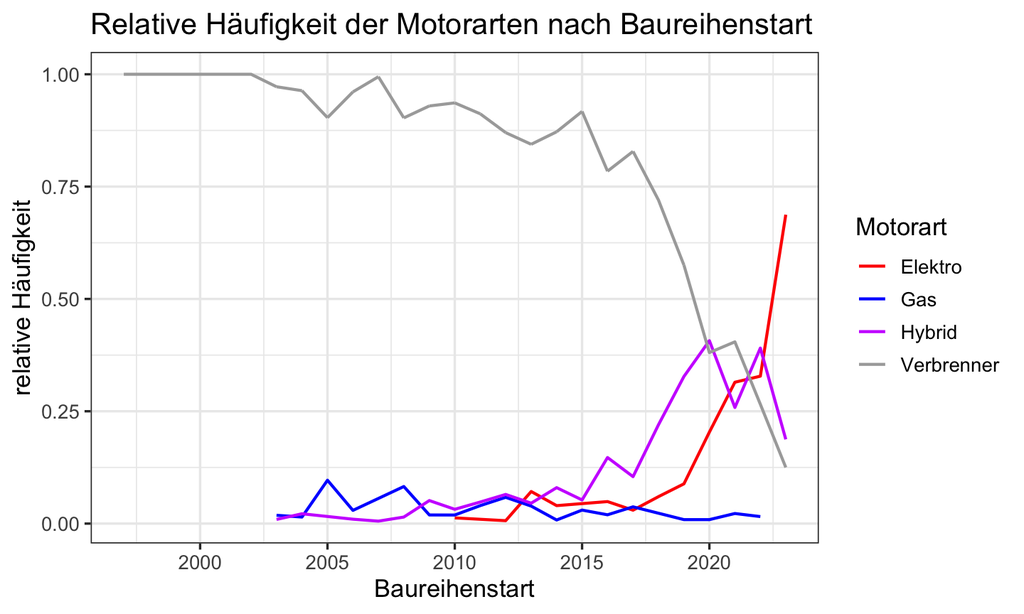

## Motorarten deutsche und ausländische Hersteller

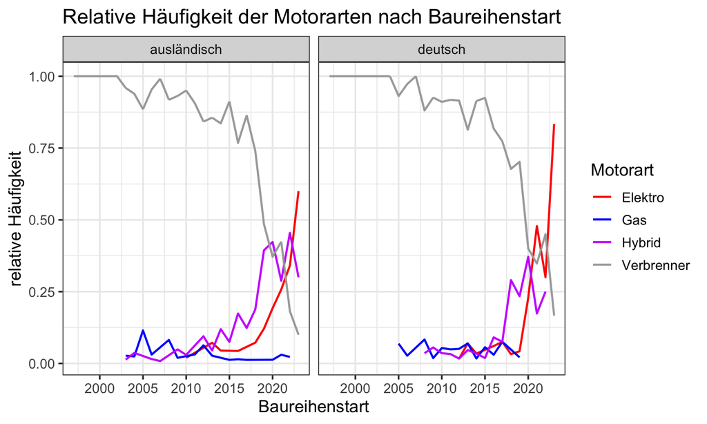

## Hubraumgröße und PS

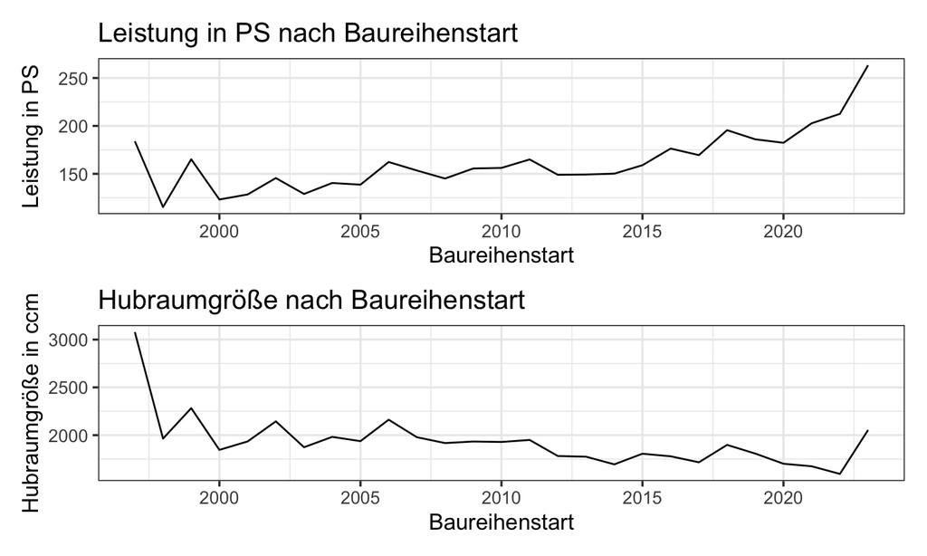

## Durchschnittlicher Grundpreis

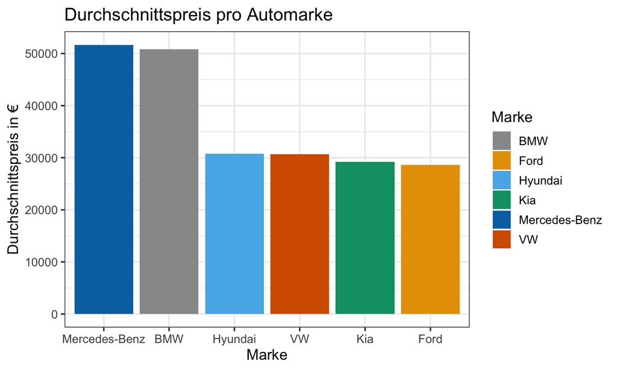

## Grundpreis der Effizienzklassen

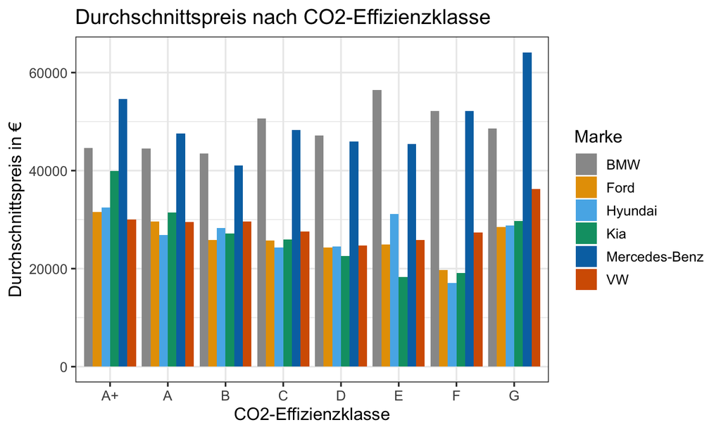

## Laufende Kosten und Wertverlust

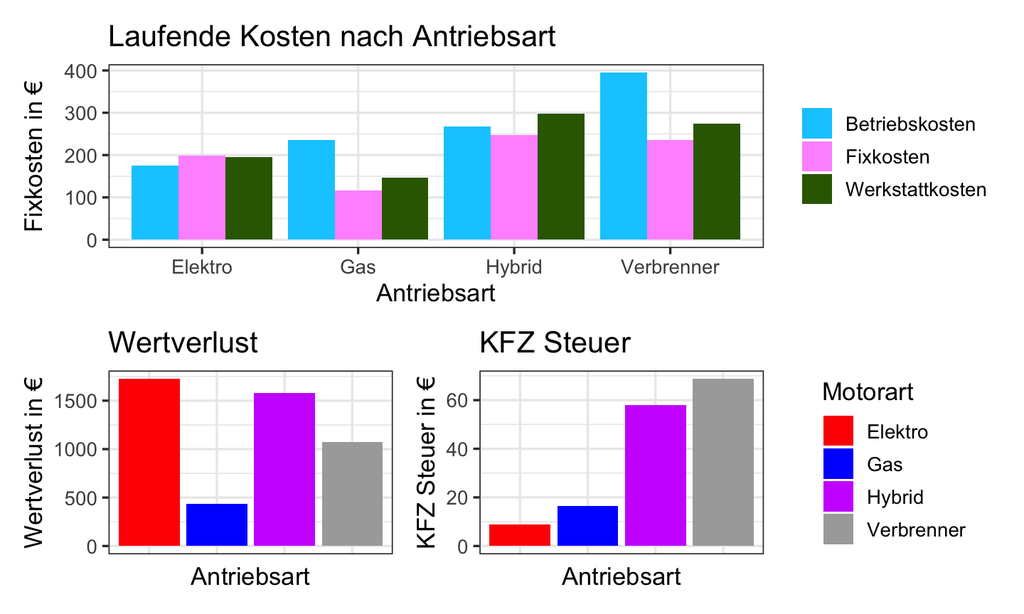

## Fahrzeuggröße

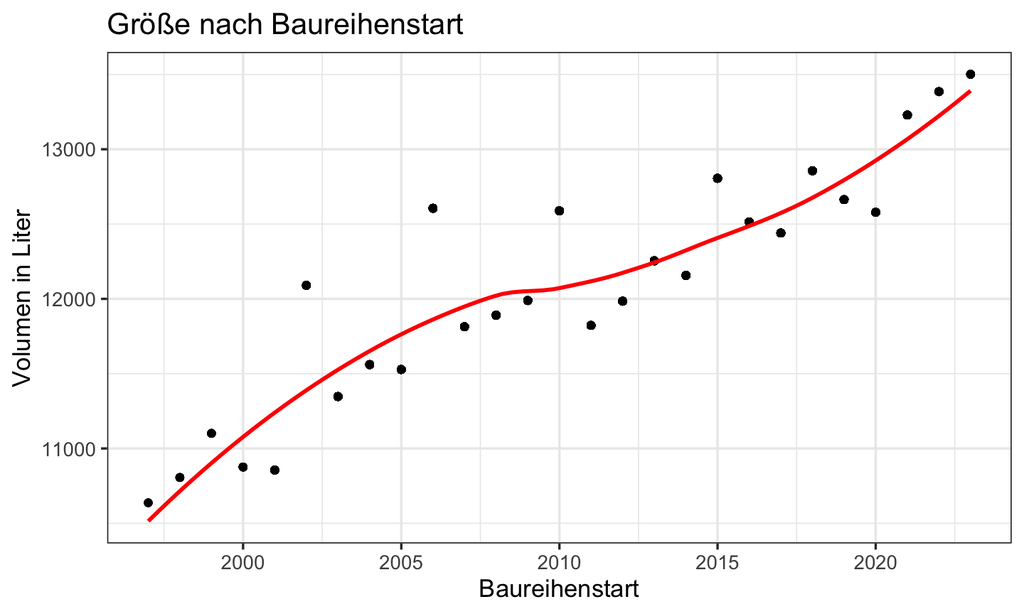

## Glättungskurve

- Auswahl konkreter x-Stellen zur Berechnung
- Auswahl der Datenpunkte im Bereich um die x-Stellen
- Berechnung der Gewichte für ausgewählte Datenpunkte
- Berechnung eines gewichteten Mittelwertes
- Approximation einer polynomiellen Funktion

## Fahrzeuggröße

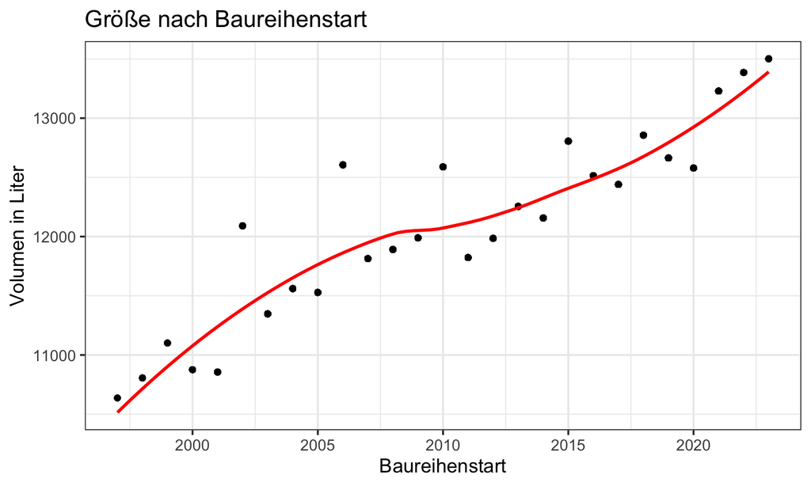

## Fahrzeuggröße nach Motorarten

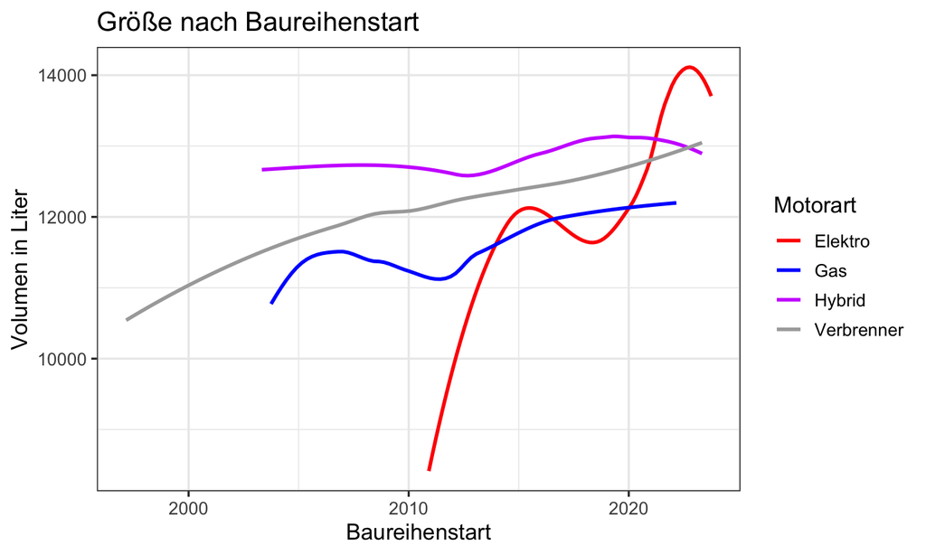

## Karosserie

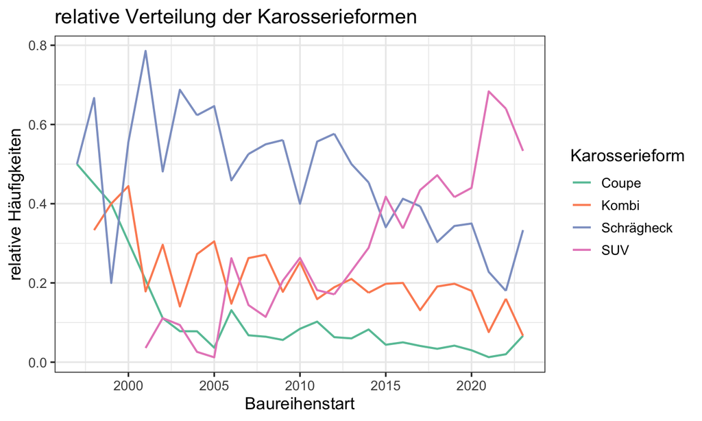

## Elektroautos Reichweite

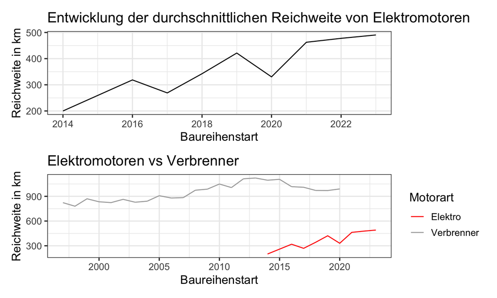

## Ladezeit und Batteriekapazität von Elektroautos

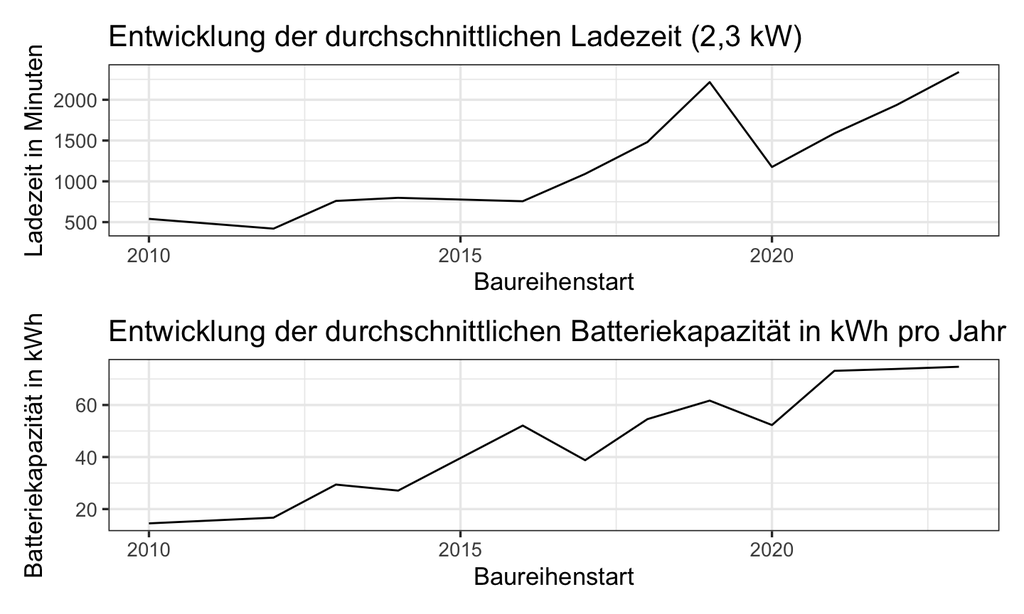

## Darstellung von Assoziationen zwischen Fahrzeugeigenschaften und der ADAC-Gesamtpunktzahl

## Gesamtpunktzahl

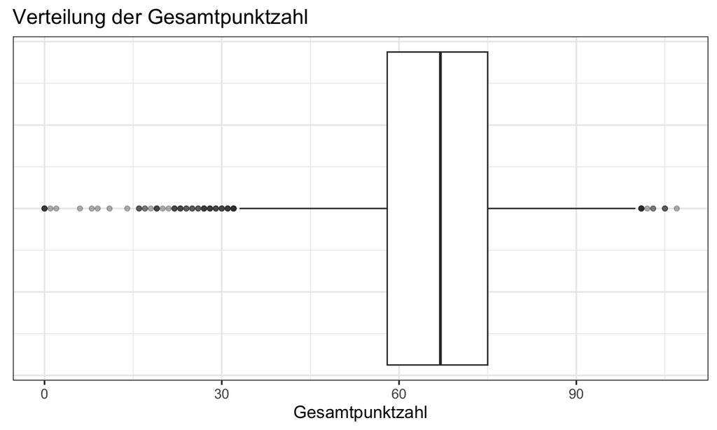

## Gesamtpunktzahl im Herstellervergleich

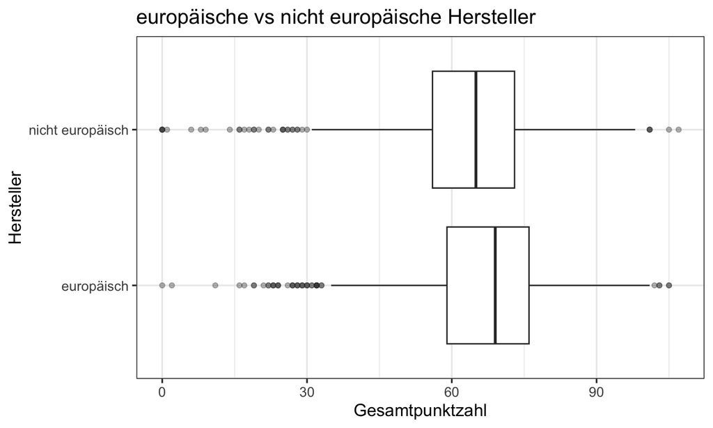

## Gesamtpunktzahl im Markenvergleich

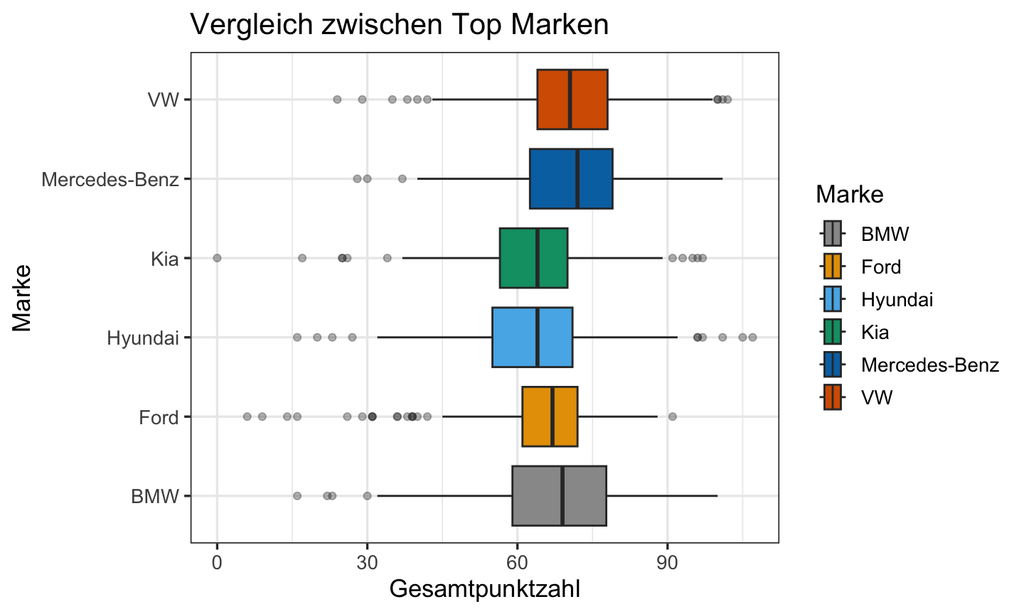

## ADAC-Ecotest und Gesamtpunktzahl

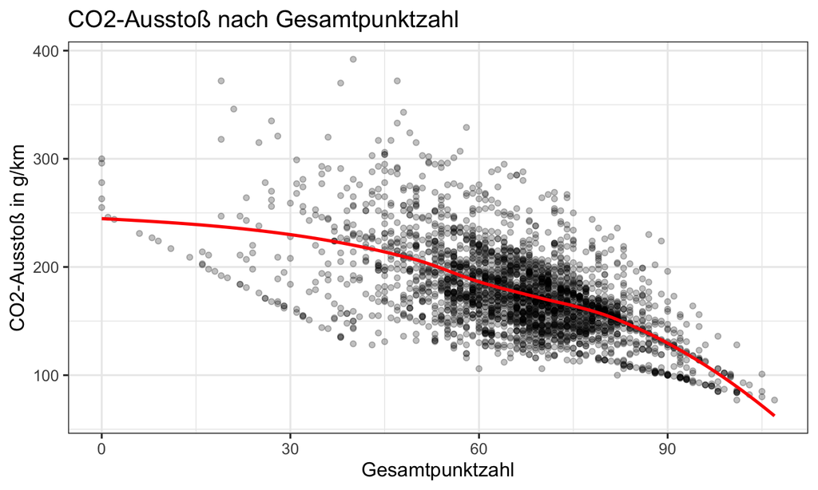

## Motorart und Gesamtpunktzahl

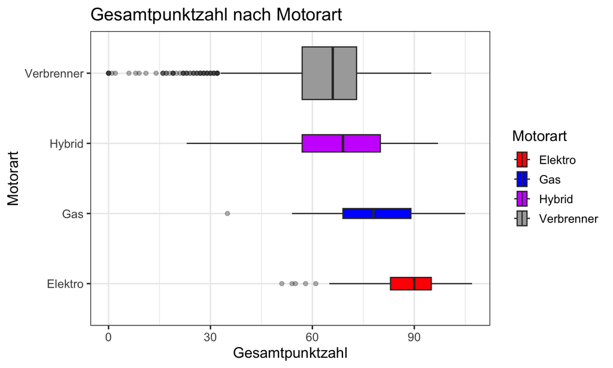

## Reichweite von Elektroautos

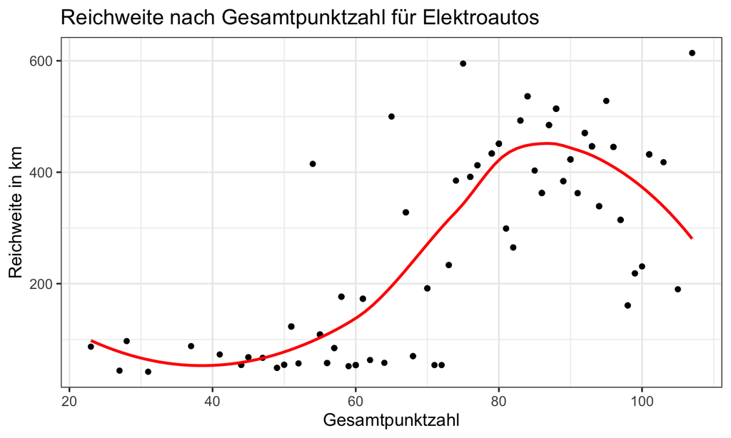

## Zusammenfassung

- CO2-Ausstoß wird geringer
- Elektroautos gewinnen an Beliebtheit
- Fahrzeuge werden größer
- Reichweite der Elektroautos werden größer

## Fragen?

- CO2-Ausstoß
- CO2 Effizienzklasse
- CO2-Ausstoß Fahrzeugklase und PS
- Verhältnis zwischen ADAC-Ecotest und Herstellerangabe
- Vergleich zwischen ADAC-Ecotest und Herstellerangabe
- Motorarten
- Motorarten deutsche und ausländische Hersteller
- Hubraumgröße und PS
- Durchschnittlicher Grundpreis
- Grundpreis der Effizienzklassen
- Laufende Kosten und Wertverlust

## Fragen?

- Fahrzeuggröße
- Fahrzeuggröße nach Motorarten
- Karosserie
- Elektroautos Reichweite
- Ladezeit und Batteriekapazität
- Gesamtpunktzahl
- Gesamtpunktzahl im Herstellervergleich
- Gesamtpunktzahl im Markenvergleich
- ADAC-Ecotest und Gesamtpunktzahl
- Motorart und Gesamtpunktzahl
- Reichweite von Elektroautos